# Futures contracts - distribution generators, claims modeling and option pricing.

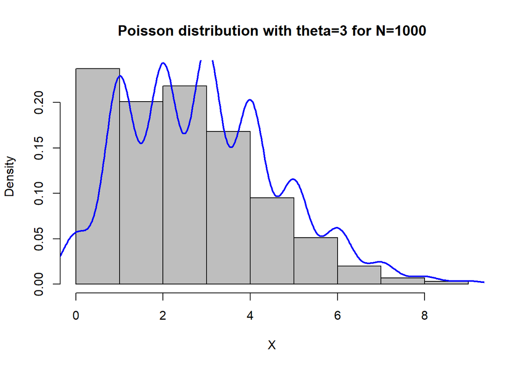

```
## [1] "Theoretical values:"
## [1] "Average:  3 , Median:  3.32666666666667"
## [1] "Variance:  3 , STD:  1"
## [1] "Generated values:"
## [1] "Average:  2.923 , Median:  3"
## [1] "Variance:  2.98605705705706 , STD:  1.72802113906545"
```

```r
pois <- poisson(N=1000,theta=3, mode="implemented")
plot_and_check_poiss(pois, theta=3, title = "Poisson distribution with theta=3 for N=1000")
```

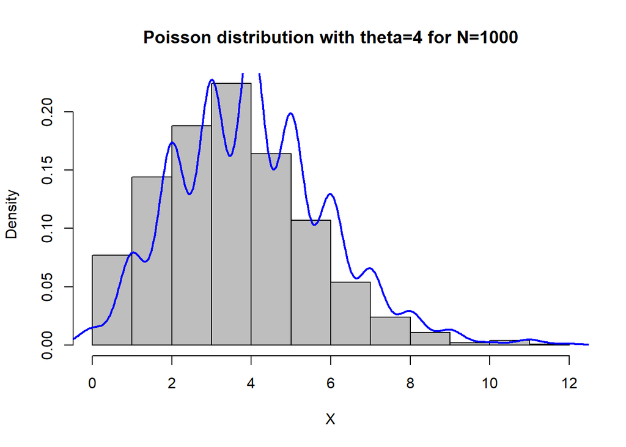

```
## [1] "Theoretical values:"
## [1] "Average:  4 , Median:  4.32833333333333"
## [1] "Variance:  4 , STD:  1"
## [1] "Generated values:"
## [1] "Average:  4.02 , Median:  4"
## [1] "Variance:  3.61321321321321 , STD:  1.90084539434779"
```

```r
pois <- poisson(N=1000,theta=4, mode="implemented")
plot_and_check_poiss(pois, theta=4, title = "Poisson distribution with theta=4 for N=1000")
```

## 2.8 Simulation of the operating time of the sorting plant

In this task, we will consider a simplified version of a clothing sorting plant, the operation scheme of which can be illustrated as follows.

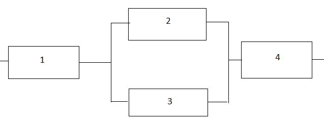

Układ sortowni

Let’s assume that $1$ stands for the device that stores clothes for sorting and lets them into the halls, in case it malfunctions, no clothes will be brought in and thus sorted which will cause the sorting plant to close temporarily. The $2$ and $3$, on the other hand, are designations for the sorting machines, they operate in parallel, so when one of them breaks down, the other can still work and the sorting room will continue to operate. On the other hand, when both break down at the same time it will also cause the work to stop. The last element is $4$, which represents the device that stores the sorted clothes and takes them out of the hall, is also crucial because its stoppage will cause the sorted clothes to stop being delivered. Each of these devices has a certain “lifespan”, which can be modeled using the appropriate distributions, more specifically:

1. device $1 \sim weibull(30.3)$,
2. device $2 \sim exp(0.05)$,
3. device $3 \sim exp(0.1)$,
4. device $4 \sim weibull(50,2)$.

Let’s denote each element with a binary variable $x_i$, where $i \in\{1,2,3,4\}$ denotes the number of the element, $x_i = 1$ when the element is fit and $x_i = 0$ when $i$th element is unfit. We will also create so-called structure functions $\phi(x) = x_1 \cdot .... \cdot x_n$ for series systems, and $\phi(x) = 1 - (1-x_1)\cdot ...\cdot(1-x_n)$ for parallel systems, where in our case the elements $1$ are connected in series with the elements $(2,3)$ and $4$, similarly $4$, while the elements $(2,3)$ are connected in parallel, and their parallel connection is a series connection with the others. We say that the system is fit when $\phi(x)=1$ and unfit when $\phi(x)=0$. Thus, in our case, we have
$$\phi(x) = x_1 \cdot (1 -
(1-x_2)\cdot(1-x_3)) \cdot x_4 = x_1 \cdot (1 - 1 + x_3 +x_2 -x_2x_3)
\cdot x_4 = x_1 \cdot (x_2 + x_3 - x_2x_3)\cdot x_4.$$
Now let’s denote by $p_i = P(x_i = 1) = E(x_i)$, which is the probability of the $i$-th element being fit at a given time. Taking into account the independence of our elements, we can decompose the theoretical reliability of the system as follows
$$E(\phi(x)) = p_1 \cdot ( p_2 + p_3 -
p_2p_3)\cdot p_4.$$
In order to simulate the running time of such a sorting plant, we will simulate by drawing from the generators we have implemented, and in order to check, we will also recalculate the theoretical reliability using built-in functions in R. The implementation of this is as follows.

```r
#---------------SIMULATION OF SYSTEM OPERATION TIME------------------------
#Theoretical reliability
r <- function(t){
  p1 = 1-pweibull(t,shape=3,scale=30)
  p2 = 1-pexp(t,0.05)
  p3 = 1-pexp(t,0.1)
  p4 = 1-pweibull(t,shape=2,scale=50)

  p1*(p2 + p3 - p2*p3)*p4
}

symulacja<-function(n){
  z <- c()
  x1 <- weibull_rand(N=n, theta=30,k=3, mode="implemented")
  x2 <- exp_rand(N=n, theta=0.05, mode="implemented")
  x3 <- exp_rand(N=n, theta=0.1, mode="implemented")
  x4 <- weibull_rand(N=n, theta=50,k=2, mode="implemented")

  w <- c()
  wx1 <- rweibull(n,shape=3,scale=30)
  wx2 <- rexp(n,0.05)
  wx3 <- rexp(n,0.1)
  wx4 <- rweibull(n,shape=2,scale=50)


  for(i in 1:n){
    z[i]<- min(x1[i], max(x2[i],x3[i]),x4[i])
    w[i]<- min(wx1[i], max(wx2[i],wx3[i]),wx4[i])
  }

  #Srednia teoretyczna:
  teor <- integrate(r,0,Inf)
  print("Theoretical average: ")
  print(teor)
  #Z symulacji:
  print("Average empirical value from own generators: ")
  print(mean(z))
  print("Empirical average value from embedded generators: ")
  print(mean(w))
  hist(z, main='Life time histogram', ylab='Frequency')

}
```

```r
symulacja(100)
```

```
## [1] "Theoretical average: "
## 15.55242 with absolute error < 1.2e-07
## [1] "Average empirical value from own generators: "
## [1] 13.84248
## [1] "Empirical average value from embedded generators: "
## [1] 16.35847
```

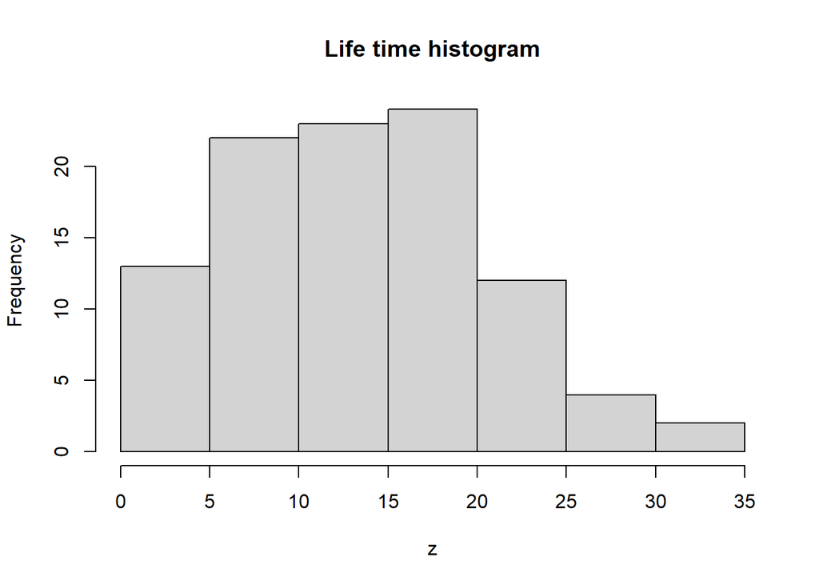

And for a more numerous simulation $n=10000$.

```r
symulacja(10000)
```

```
## [1] "Theoretical average: "
## 15.55242 with absolute error < 1.2e-07
## [1] "Average empirical value from own generators: "
## [1] 15.61711
## [1] "Empirical average value from embedded generators: "
## [1] 15.70109
```

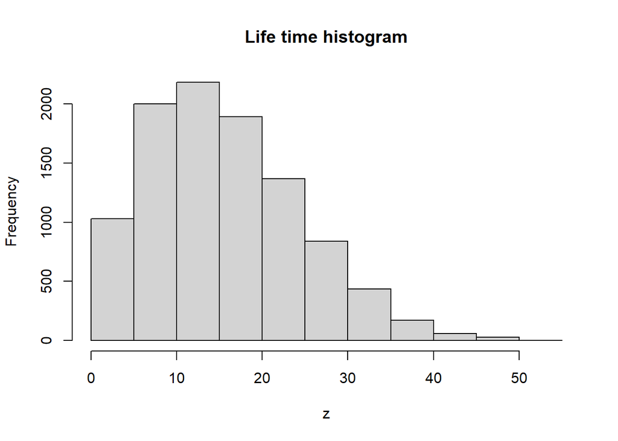

The theoretical values, of course, do not change, but it is certain that a more numerous sample offers greater model stability. As you can see, both with our own and built-in generators, results close to the theoretical one were obtained. We just calculated the theoretical average value of the sorting plant’s operating time, which is about 15 days. In addition, we have prepared a simulation using pseudo-random number generators from the exponential and Weibull distribution (our own as well as built-in) through which we have shown the validity of the theoretical result. In addition, we are able to visualize by means of a histogram, the average uptime of sorting plants with such equipment, whose uptime can be expressed using these distributions.

## 2.9 Summary

In this report, a superficial theory has been introduced on how to create pseudorandom number generators derived from distributions such as exponential, Weibull, arcsine, normal (by two methods) and Poisson distributions using a number generator from a uniform distribution. Here we have taken both our own linear congruence generator, as well as in further considerations, in order to standardize, an embedded generator. We showed once again the relevance of the assumptions of the linear congruence generator and their effect on the results with particular other distributions. Most of it was based on the inverse transformation method, although there was also a part involving a rejection test. Moreover, Muller’s box algorithm and the double exponential method for generating numbers from a standard normal distribution were also presented. Finally, the constructed exponential and Weibull generators were used to perform the task of simulating the average uptime of a certain sorting plant, which was briefly described in the introduction.

# 3 Modeling the size of insurance claims by Gamma distribution

## 3.1 Introduction

This paper will briefly present a theoretical approach to the topic of generating numbers from the Gamma distribution, and then two generators from this distribution will be implemented. The first will be a generator created using the GKM1 algorithm, while the second will be based on the Ahrens-Dieter algorithm. The times, as well as the average iteration numbers from both implementations will be compared.

The Poisson distribution number generator created in the last project will also be cited, with a slight modification to exclude the use of an in-house uniform distribution number generator due to the use of a built-in generator. Later, the insurance claims process will be modeled using the aforementioned generator, as well as the implemented generator of numbers from the Gamma distribution.

## 3.2 Gamma distribution

Gamma distribution with a shape parameter $a$ and a scale $beta$ has a mensuration equal to
$$f(y) = f_{a, \beta}(y) = \frac{1}{\Gamma
(a)\beta^a}y^{a-1}e^{-y/\beta}, \quad y\geq 0$$
Such a distribution has a mean equation of $a\beta$ and a variance of $a\beta^2$. We can distinguish sampling methods from the Gamma distribution into those that consider the situation for $a \leq 1$ and $a > 1$. When using the generator to model interest rates, in most cases we will encounter the situation with $a>1$, while the situation for $a \leq 1$ will also be considered. On the other hand, there is no loss of generality when assuming $a = 1$, because if $X$ has a Gamma distribution with parameters $(a,1)$ then $a X$ has a Gamma distribution with parameters $(a, \beta)$.

We will also create a function to plot the density.

```r
plot_hist <- function(X){
  if( typeof(X) == "list"){
    S <- unlist(X[1])
    iters <- unlist(X[2])
    title = "Histogram X - implemented generator"
    txt = "Generator implemented"
    print(paste("Number of iterations: ",iters, sep=""))
  } else {
    S <- X
    title = "Histogram X - built-in generator"
    txt = "Built-in generator"
  }
  hist(S, prob=TRUE, col="grey", xlab = "X", main = title)
  lines(density(S), col="blue", lwd=2)
  print(paste(txt, " average: ", mean(S), sep=""))
  print(paste(txt, " variance: ", var(S), sep=""))

}
```

## 3.3 GKM1 algorithm.

Suppose that some function $f$ is non-negative and integral on the set $[0, \infty)$. If $(X,Y)$ has a uniform distribution on the set $A = \{(x,y): x \leq \sqrt{f(y/x)}\}$ then the density of $Y/X$ is proportional to $f$. Thus, to uniformly sample from $A$ we can recursively, uniformly select pairs $(X,Y)$ from the rectangle and keep the first ones for which $X \leq \sqrt{f(Y/X)}$. In order to sample from the Gamma density with parameter $a > 1$, we will define a set $A$, viz.
$$A = \{(x,y): 0\leq x \leq
\sqrt{[(y/x)^{a-1}e^{-y/x}}\}$$
This set is contained in the rectangle $[0,\overline{x}]\times [0,\overline{y}]$ where $\overline{x} = [(a-1)/e]^{(a-1)/2}$. Sampling uniformly from this rectangle, the expected number of samples needed to time the dropout in $A$ is determined by the ratio of the dimension of $A$ to the dimension of this rectangle. It is defined by $O(\sqrt{a})$, so the time needed to generate a sample with this method increases with the shape parameter. In the GKM1 algorithm, we have an acceptance test performed first, which reduces the number of logarithmic transformations. Below is the implemented algorithm.

```r
gkm1 <- function(a, beta, N){
  if(a <= 1){
    return("Invalid parameter a!")
  } else {
    ap <- a-1
    b <- (a-(1/(6*a)))/ap
    m <- 2/ap
    d <- m+2

    niter <- 0
    X <- c()

    while(length(X) < N){
      sample <- "Reject"
      while(sample != "Accept"){
        niter <- niter + 1
        U1 <- runif(1)
        U2 <- runif(1)
        V <- b*U2/U1

        check1 <- m*U1 - d + V + (1/V)
        check2 <- m*log(U1) - log(V) + V - 1

        if(check1 <= 0){
          sample <- "Accept"
        } else if(check2 <= 0){
          sample <- "Accept"
        } else {
          sample <- "Reject"
        }
      }
    X <- append(X, beta*ap*V)
    }
  }

  return(list(X, niter))
}
```

## 3.4 Ahrens-Dieter algorithm.

The Ahrens-Dieter algorithm handles the case when $a \leq 1$. It generates “candidates” by sampling from distributions centered on the intervals $[0,1]$ and $(1, \infty)$ with appropriate probabilities. In particular, let $p = e/(a + e)$ and
$$g(z) = \left\{ \begin{array}{ll} paz^{a-1},
& 0 \leq z \leq 0\\
(1-p)e^{-z+1}, & z > 1.\end{array} \right.$$
This is a density that is a “mixture” of the densities $az^{a-1}$ on $[0,1]$ and $e^{-z+1}$ on $(1,\infty)$ with corresponding weights $p$ and $(1-p)$. We can sample from $g$ by sampling from each of these densities with an assigned probability. Each of these two densities is easily sampled using the inverse transform method, i.e., for the density $az^{a-1}$ we can use $U^{1/a}$, where $U \sim Unif[0,1]$ and for the density $e^{-z+1}$ we have $1-log(U)$. Samples with $g$ are suitable candidates for the accept-rejection method because the ratio $f_{a,1}(z)/g(z)$ with $f_{a,1}$ Gamma density is limited. Insight into this ratio reveals that candidate $Z$ on the interval $[0,1]$ is accepted with probability $e^{-Z}$, and candidate $(1, \infty)$ is accepted with probability $Z^{a-1}$. The global ratio constraint is given by
$$f_{a,1}(z) / g(z)
\leq \frac{a+e}{ae\Gamma(a)} \leq 1.39,$$
where it is worth recalling that the upper bound on the restriction of such a proportion determines the expected number of candidates generated with the accepted sample. In the following algorithm, it is worth noting that when the condition $Yleq 1$ fails then $Y$ has a uniform distribution on $[1,b]$ which means that $(b-Y)/a$ has a distribution $U/e$ ($U \sim Unif[0,1]$), and thus $-log((b-Y)/a)$ has a distribution $1-log(U)$.

```r
adr <- function(a, beta, N){
  if(a > 1){
    return("Invalid parameter a!")
  } else {
    b <- (a + exp(1))/exp(1)

    niter <- 0
    X <- c()

    while(length(X) < N){
      sample <- "Reject"
      while(sample != "Accept"){
        niter <- niter + 1
        U1 <- runif(1)
        U2 <- runif(1)
        Y <- b*U1

        if (Y <= 1){
          Z <- Y^(1/a)
          if (U2 < exp(-Z)){
            sample <- "Accept"
          }
        } else {
          Z <- -log((b-Y)/a)
          if (U2 <= Z^(a-1)){
            sample <- "Accept"
          }
        }
      }
    X <- append(X, beta*Z)
    }
  }

  return(list(X, niter))
}
```

## 3.5 Testing

After implementing both algorithms, we will prepare a function that will allow us to freely use the generator of numbers from the Gamma distribution depending on the assumed shape parameter $a$.

```r
gam <- function(a, beta, N, unlist=FALSE){
  if (a <= 1){
    G <- adr(a,beta,N)
  } else {
    G <- gkm1(a, beta, N)
  }

  if (unlist){
    G <- unlist(G[1])
  }
  return(G)
}
```

```
## [1] "Number of iterations: 1397"
```

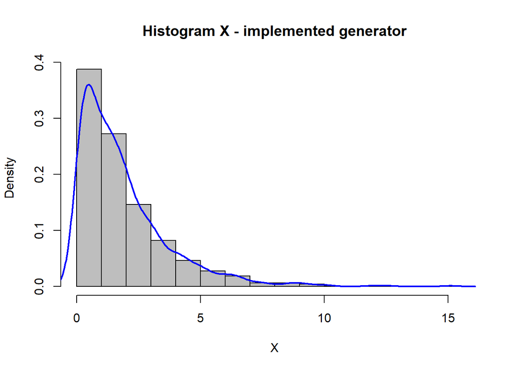

```
## [1] "Generator implemented average: 1.86756842175227"
## [1] "Generator implemented variance: 3.35625451494779"
```

```r
G1 <- gam(1,2,1000)
G2 <- rgamma(n=1000, scale=2, shape=1)
plot_hist(G1)
```

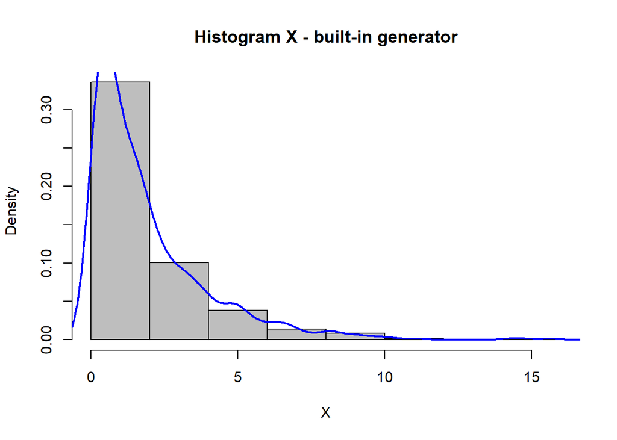

```
## [1] "Built-in generator average: 1.9147800751746"
## [1] "Built-in generator variance: 4.14613860675843"
```

```r
plot_hist(G2)
```

We can easily see the convergence of the two samples. Let’s check, then, the situation for the parameters $a = 0.5$ and $\beta = 1$.

```
## [1] "Number of iterations: 1375"
```

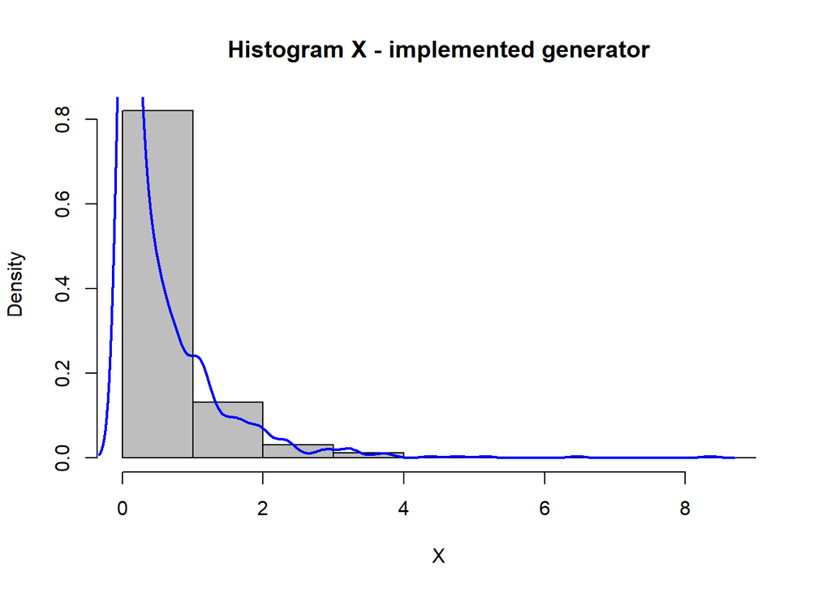

```
## [1] "Generator implemented average: 0.524375067777741"
## [1] "Generator implemented variance: 0.577592989761137"
```

```r
G1 <- gam(0.5,1,1000)
G2 <- rgamma(n=1000, scale=1, shape=0.5)
plot_hist(G1)
```

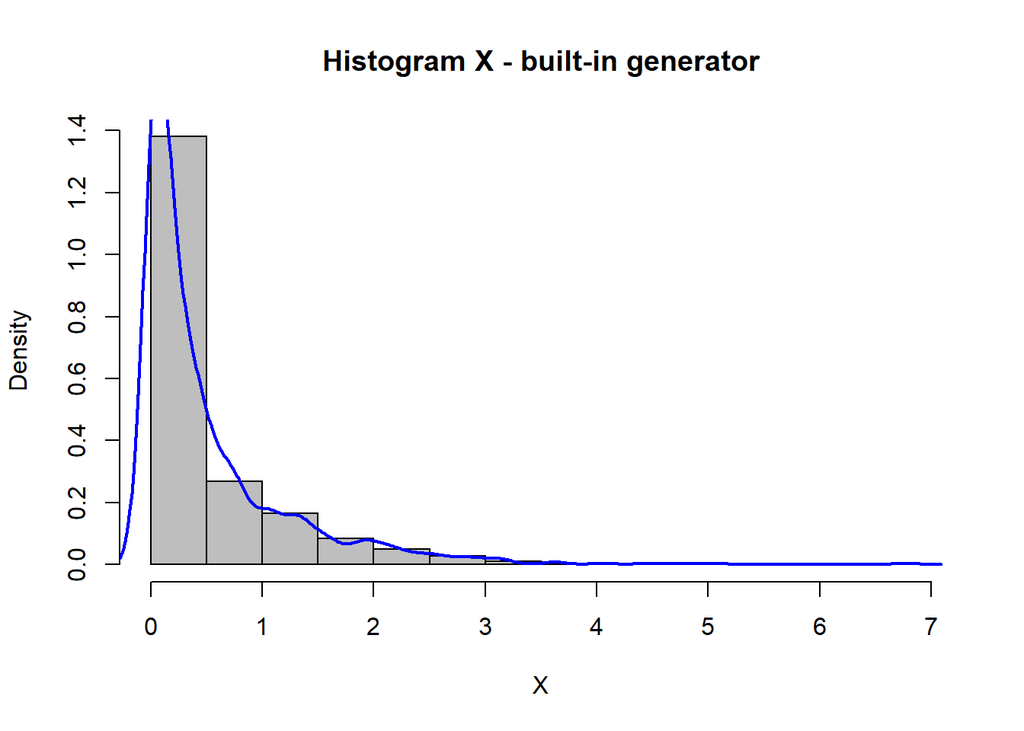

```
## [1] "Built-in generator average: 0.510526624056974"
## [1] "Built-in generator variance: 0.518556234290907"
```

```r
plot_hist(G2)
```

Again, the histograms are close to each other. This demonstrates the correctness of the implemented algorithm and the achievement of correct sample results for the case $a<=1$. Moreover, it shows the actual lack of loss of generality when assuming $a=1$ during implementation and multiplying by this factor in the final stage. Let’s see the situation for $a>1$, so let’s consider $a = 2$ and $\beta = 2$.

```
## [1] "Number of iterations: 1406"
```

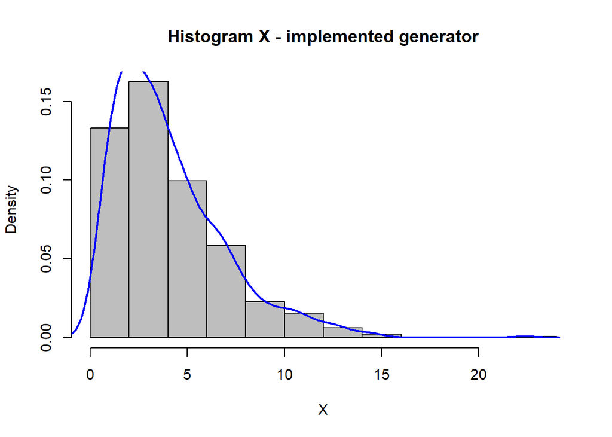

```
## [1] "Generator implemented average: 4.04409556146654"
## [1] "Generator implemented variance: 8.01594686990055"
```

```r
G1 <- gam(2,2,1000)
G2 <- rgamma(n=1000, scale=2, shape=2)
plot_hist(G1)
```

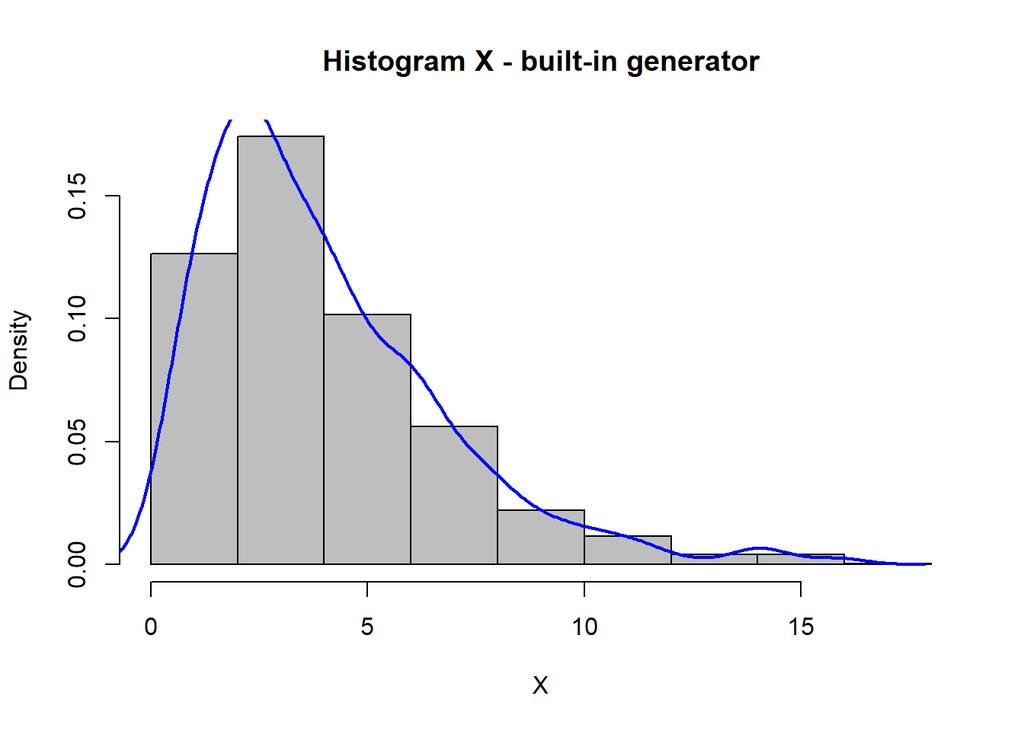

```
## [1] "Built-in generator average: 3.9687052172932"
## [1] "Built-in generator variance: 7.67580018668196"
```

```r
plot_hist(G2)
```

Again, as expected, we also get convergence of the two histograms. Let’s consider some more $a = 9$ and $beta = 0.5$.

```
## [1] "Number of iterations: 2424"
```

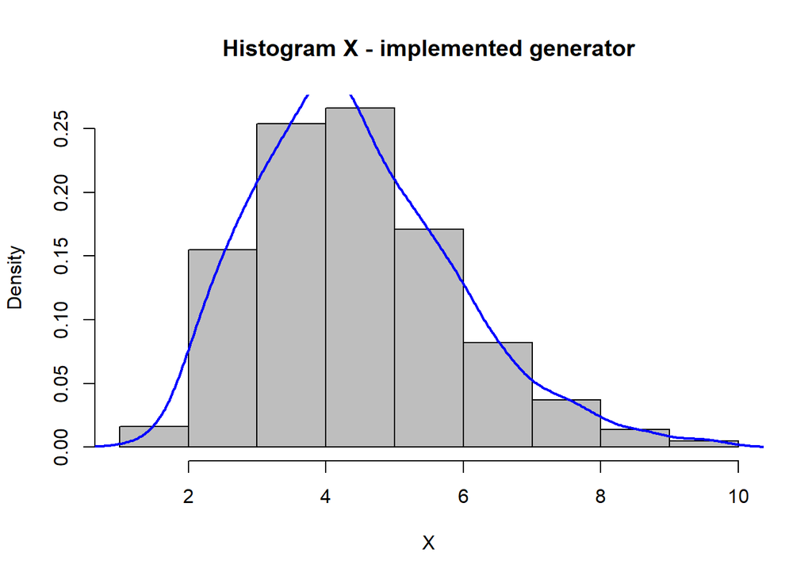

```
## [1] "Generator implemented average: 4.41661965172702"
## [1] "Generator implemented variance: 2.12871726438368"
```

```r
G1 <- gam(9,0.5,1000)
G2 <- rgamma(n=1000, scale=0.5, shape=9)
plot_hist(G1)
```

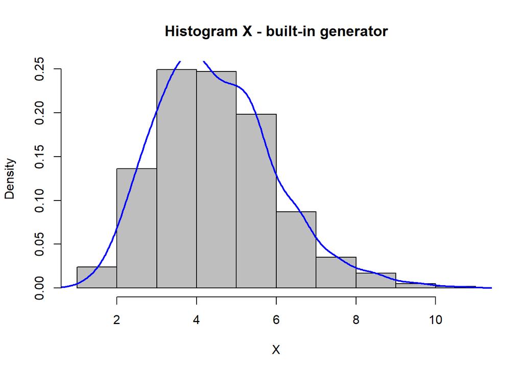

```
## [1] "Built-in generator average: 4.48440574318353"
## [1] "Built-in generator variance: 2.23520178351816"
```

```r
plot_hist(G2)
```

Indeed, the values are still close. Moreover, in addition to the visual comparison, we can see that despite small deviations, the values of the statistics (mean and variance) are close to each other. We conclude from this that the implemented algorithm for generating a sample from the gamma distribution is correct.

The next thing we will check is the time and number of iterations needed to generate a sample depending on the assumed parameter $a$, as we then use different algorithms. Let’s first check for $N \in\{100, 1000, 5000, 10000, 20000\}$ with $a = 0.5$ as $a <=1$ (so Ahrens-Dieter algorithm) and $a=2$ as $a>1$ (GKM1 algorithm).

```r
iters1 <- c()
time1 <- c()
iters2 <- c()
time2 <- c()
x <- c()
N <- c()
for (n in c(100, 1000, 5000, 10000, 20000)){
  N <- append(N, n)

  start.time <- as.numeric(as.numeric(Sys.time())*1000, digits=15)
  G1 <- gam(0.5, 2, N=n)
  end.time <-  as.numeric(as.numeric(Sys.time())*1000, digits=15)
  t1 <- end.time - start.time


  iters1 <- append(iters1, unlist(G1[2]))
  time1 <- append(time1, t1)

  start.time <- as.numeric(as.numeric(Sys.time())*1000, digits=15)
  G2 <- gam(2, 2, N=n)
  end.time <-  as.numeric(as.numeric(Sys.time())*1000, digits=15)
  t2 <- end.time - start.time


  iters2 <- append(iters2, unlist(G2[2]))
  time2 <- append(time2, t2)

  print(paste("Number of iterations for a <=1: ", unlist(G1[2]), " with N=", n,sep=""))
  print(paste("Number of iterations for a >1: ", unlist(G2[2]), " with N=", n, sep=""))

  print(paste("The execution time of the algorithm for a <=1: ", t1, " with N=", n,sep=""))
  print(paste("The execution time of the algorithm for a >1: ", t2, " with N=", n, sep=""))

}
```

```
## [1] "Number of iterations for a <=1: 133 with N=100"
## [1] "Number of iterations for a >1: 144 with N=100"
## [1] "The execution time of the algorithm for a <=1: 0.743896484375 with N=100"
## [1] "The execution time of the algorithm for a >1: 0.765869140625 with N=100"
## [1] "Number of iterations for a <=1: 1344 with N=1000"
## [1] "Number of iterations for a >1: 1404 with N=1000"
## [1] "The execution time of the algorithm for a <=1: 13.4990234375 with N=1000"
## [1] "The execution time of the algorithm for a >1: 9.0751953125 with N=1000"
## [1] "Number of iterations for a <=1: 6620 with N=5000"
## [1] "Number of iterations for a >1: 7097 with N=5000"
## [1] "The execution time of the algorithm for a <=1: 100.10302734375 with N=5000"
## [1] "The execution time of the algorithm for a >1: 158.4619140625 with N=5000"
## [1] "Number of iterations for a <=1: 13388 with N=10000"
## [1] "Number of iterations for a >1: 14114 with N=10000"
## [1] "The execution time of the algorithm for a <=1: 246.5009765625 with N=10000"
## [1] "The execution time of the algorithm for a >1: 221.31396484375 with N=10000"
## [1] "Number of iterations for a <=1: 26712 with N=20000"
## [1] "Number of iterations for a >1: 28189 with N=20000"
## [1] "The execution time of the algorithm for a <=1: 596.7392578125 with N=20000"
## [1] "The execution time of the algorithm for a >1: 528.40673828125 with N=20000"
```

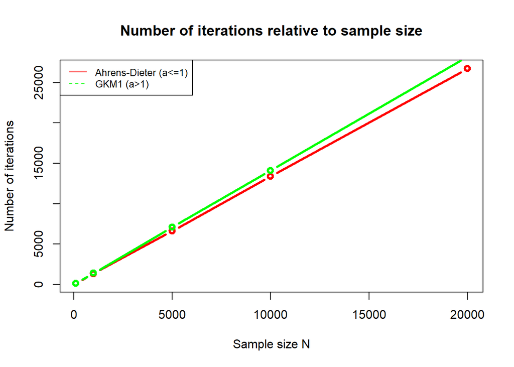

```r
plot(N, iters1,  type = "b", col = "red" , lwd = 3, pch = 1, xlab="", ylab="")
lines(N, iters2, type = "b", col = "green" , lwd = 3, pch = 1)
title(main = "Number of iterations relative to sample size", xlab = "Sample size N", ylab="Number of iterations")
legend("topleft", legend=c("Ahrens-Dieter (a<=1)", "GKM1 (a>1)"), col=c("red","green"),lty=1:2, cex=0.8)
```

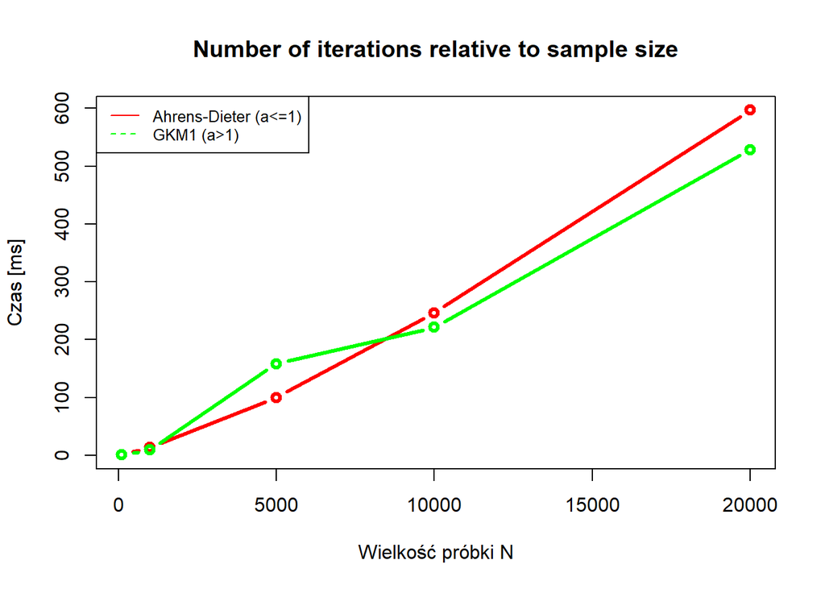

```r
plot(N, time1,  type = "b", col = "red" , lwd = 3, pch = 1, xlab="", ylab="")
lines(N, time2, type = "b", col = "green" , lwd = 3, pch = 1)
title(main = "Number of iterations relative to sample size", xlab = "Wielkość próbki N", ylab="Czas [ms]")
legend("topleft", legend=c("Ahrens-Dieter (a<=1)", "GKM1 (a>1)"), col=c("red","green"),lty=1:2, cex=0.8)
```

We can see that both the number of iterations and the sample generation time are similar for both algorithms. Of course, there are some deviations, but they are not significant. This is very well shown in the above visualization, where we can see how, as expected, the number of iterations as well as the duration increases with the sample, but the values for both algorithms are close to each other. However, it can also be seen that for the Ahrens-Dieter algorithm the time increases faster than for the GKM1 algorithm.

## 3.6 Modeling the insurance claims process

In order to model the insurance claims process, we will use the implemented generator from the Gamma distribution and a slightly modified generator from the Poisson distribution from the previous part of the project, i.e.

```r
poisson <- function(N,theta){
    X <- c()
    while(length(X) < N){
      p <- exp(-theta)
      Fd <- p
      Nbig <- 0


      U <- runif(2)
      U1 <- U[2]

      while (U1 > Fd){
        Nbig <- Nbig + 1
        p <- p*theta/Nbig
        Fd <- Fd + p
        }
      X <- append(X,Nbig)
      }
    return(X)
}
```

In this chapter, we will model the insurance claims process by building a probabilistic model to describe the process of occurrence of aggregate insurance claims over a certain time period. Such an insurance system can be composed of a single policy or a group of insurance contracts. Aggregate claims are the sum of all claims served over a certain period of time. We can then distinguish between the individual risk model, which considers the loss from each individual contract, or the aggregate risk model, which models approaches that consider the distribution of frequency as well as severity of claims. It can be represented as
$$S_N = X_1 + X_2 +... +
X_N,$$
Where $N$ is a random variable denoting the number of losses (or the number of payouts). Naturally, we can assume $X_i>0$, because when $X_i = 0$ we have no claim. We assume that $N=n, X_1, X_2, ..., X_n$ are independent random variables with equal distributions.

The distribution of $N$ is known as the frequency distribution. In our case, we will use the Poisson distribution, which is one of the known discrete distributions (besides, the binomial and negative binomial distributions are popular). As is known, we can consider this distribution as a distribution counting the number of occurrences of some random event in a certain unit of time, and therefore also counting the number of insurance claims in a given period.

In turn, the joint distribution of $X$ is known as the severity distribution. Since we approach the model of the insurance claims process through the collective risk model then we rely on separate modeling of the frequency and amount of claims. In such a situation, it is popular to use, as written above, frequency modeling through a Poisson process along with Gamma distribution modeling of claim amounts. In addition to this, a Pareto or Weibull distribution is also used.

Our model algorithm is as follows:

1. We assume a collective risk model $S_N = X_1 + .... + X_N$;
2. let $j = 1, ..., m$ be an iterator set from $j=1$;
3. We generate the number of claims $n_j$ from the frequency distribution $N$;
4. Given a value of $n_j$, we generate the amount of each claim independently from the severity distribution $X$ denoted by $x_{1j}, ..., x_{n_jj}$;
5. we recalculate the aggregate loss $s_j = x_{1j} + ... + x_{n_jj}$;
6. we repeat the above three steps for $j=2, ..., m$ obtaining a sample $S_N$ of size $m$, i.e. ${s_1, ..., s_m}$.

For our model, we consider the frequency distribution $N \sim Poiss(\lambda = 25)$ and the claim height distribution $X \sim Gamma(5, 2)$. The simulation code aggregated claim height is presented below.

```r
insurance_model <- function(t, lambda=25, a=5, beta=2, seed=123){
  set.seed(seed)
  S <- rep(NA,t)

  n <- poisson(t, theta=lambda)
  for (j in 1:t){
    n_j <- n[j]
    x_j <- gam(a, beta, n_j, unlist=TRUE)
    s_j <- sum(x_j)
    S[j] <- s_j
  }
  return(S)

}
```

Let’s see how it creates for the time $t = 12$ months with the given parameters.

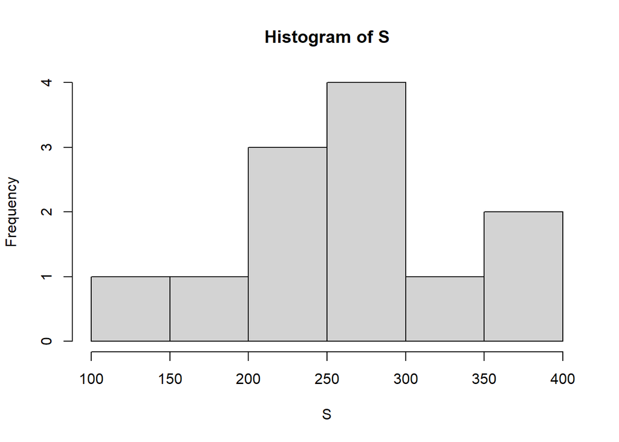

```r
S <- insurance_model(t=12)
hist(S)
```

```r
print(paste("Total claims per 12-month interval: ", sum(S), sep=""))
```

```
## [1] "Total claims per 12-month interval: 3149.08704382361"
```

We can see that the modeled sum of claims with these parameters is the corresponding amount in zlotys (let’s assume for simplicity that our unit is the Polish zloty). In turn, from the histogram we can read the most common claim amounts. Let’s check what is the probability, with these coefficients of frequency distributions and claim heights, that at time $t=12$ months the sum of claims will exceed $K=3000$ PLN. We will create a function to help estimate the probability for other sets of parameters.

```r
insurance_model_probability <- function(K, t, N = 1000, lambda=25, a=5, beta=2){
  p = 0
  for (i in 1:N){
    seed = i

    S <- insurance_model(t = t, lambda = lambda, a = a, beta = beta, seed=seed)

    if (sum(S) > K){
      p = p+1
    }
  }

  prob = p/N

  print(paste("Probability of exceeding the sum K: ", K, " in time t: ", t, " equals: ", prob,       " for the parameters lambda= ", lambda, " ,a= ", a, " ,beta= ", beta, ".",sep=""))

  return(c(t, K, prob))
  }
```

```r
str1 <- insurance_model_probability(K = 3000,  t=12)
```

```
## [1] "Probability of exceeding the sum K: 3000 in time t: 12 equals: 0.475 for the parameters lambda= 25 ,a= 5 ,beta= 2."
```

This means that, given the parameters, we are more likely to lose less than $3,000. Let’s check how this probability changes on the range $[2950, 3350]PLN with a jump in $100 increments.

```r
K <- c()
prob <- c()
for (ks in seq(2950,3350,100)){
    K <- append(K, ks)
    str1 <- insurance_model_probability(K = ks,  t=12)
    prob <- append(prob, str1[3])
}
```

```
## [1] "Probability of exceeding the sum K: 2950 in time t: 12 equals: 0.574 for the parameters lambda= 25 ,a= 5 ,beta= 2."
## [1] "Probability of exceeding the sum K: 3050 in time t: 12 equals: 0.381 for the parameters lambda= 25 ,a= 5 ,beta= 2."
## [1] "Probability of exceeding the sum K: 3150 in time t: 12 equals: 0.205 for the parameters lambda= 25 ,a= 5 ,beta= 2."
## [1] "Probability of exceeding the sum K: 3250 in time t: 12 equals: 0.096 for the parameters lambda= 25 ,a= 5 ,beta= 2."
## [1] "Probability of exceeding the sum K: 3350 in time t: 12 equals: 0.033 for the parameters lambda= 25 ,a= 5 ,beta= 2."
```

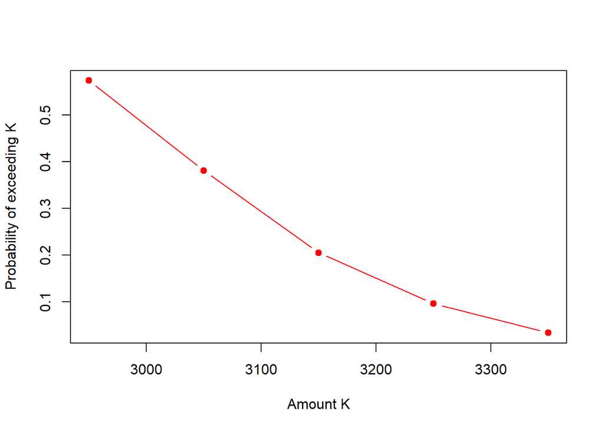

```r
plot(x= K, y=prob, type = "b", pch = 19, col="red", xlab= "Amount K", ylab = "Probability of exceeding K")
```

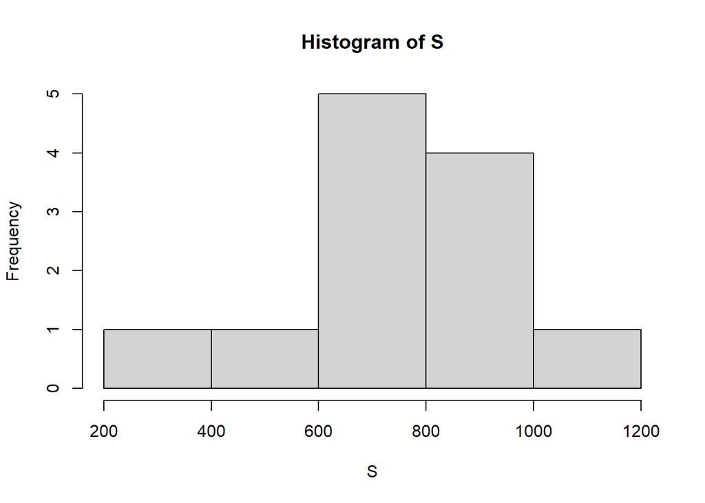

```r
S <- insurance_model(t=12, lambda = 15, a = 9, beta=5)
hist(S)
```

```r
print(paste("Total claims per 12-month interval: ", sum(S), sep=""))
```

```
## [1] "Total claims per 12-month interval: 9010.1470197877"
```

```r
K <- c()
prob <- c()
for (ks in seq(7800,8200,100)){
    K <- append(K, ks)
    str1 <- insurance_model_probability(K = ks,  t=12, lambda=15, a = 9, beta = 5)
    prob <- append(prob, str1[3])
}
```

```
## [1] "Probability of exceeding the sum K: 7800 in time t: 12 equals: 0.659 for the parameters lambda= 15 ,a= 9 ,beta= 5."
## [1] "Probability of exceeding the sum K: 7900 in time t: 12 equals: 0.594 for the parameters lambda= 15 ,a= 9 ,beta= 5."
## [1] "Probability of exceeding the sum K: 8000 in time t: 12 equals: 0.538 for the parameters lambda= 15 ,a= 9 ,beta= 5."
## [1] "Probability of exceeding the sum K: 8100 in time t: 12 equals: 0.479 for the parameters lambda= 15 ,a= 9 ,beta= 5."
## [1] "Probability of exceeding the sum K: 8200 in time t: 12 equals: 0.415 for the parameters lambda= 15 ,a= 9 ,beta= 5."
```

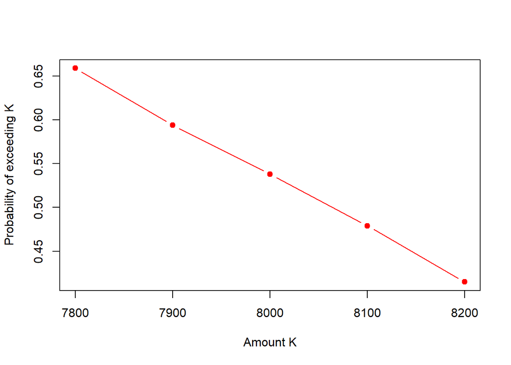

```r
plot(x= K, y=prob, type = "b", pch = 19, col="red", xlab= "Amount K", ylab = "Probability of exceeding K")
```

We see that here the probability is already falling at a much slower rate. Not surprisingly, in this case we expect an average frequency of 15 claims with a higher expected value which is due to the properties of Gamma and Poisson distributions. Using these two sets of parameters as an example, let’s further examine the effect of the time period and change $t = 24$ months, a period of two years. First we will again look at the distributions of the sum of claims. For the first set of parameters:

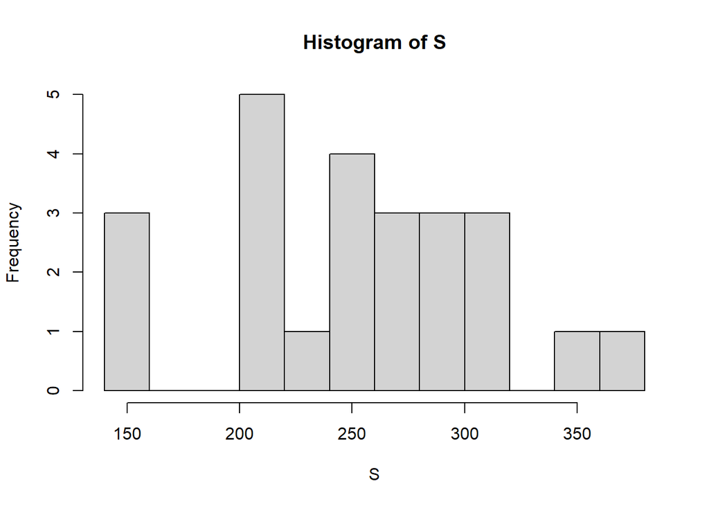

```r
S <- insurance_model(t=24)
hist(S, breaks = 15)
```

```r
print(paste("Total claims per 24-month interval: ", sum(S), sep=""))
```

```
## [1] "Total claims per 24-month interval: 6092.67062304503"
```

And for the second set:

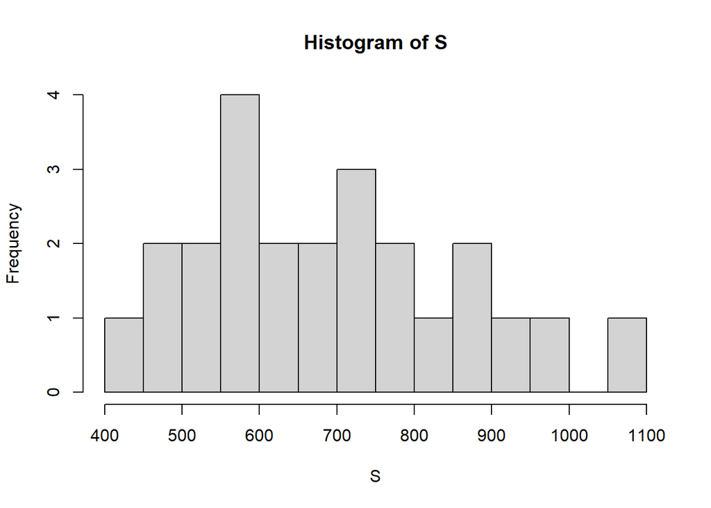

```r
S <- insurance_model(t=24, lambda = 15, a = 9, beta=5)
hist(S, breaks = 15)
```

```r
print(paste("Total claims per 24-month interval: ", sum(S), sep=""))
```

```
## [1] "Total claims per 24-month interval: 16602.6760770984"
```

Naturally, the amount of claims has increased due to the extended number of possible time jumps, and the increase is nearly double as the period has increased. Let’s see the effect on probability by setting $K$ on the range $[5900, 6300]$ and $[16400, 16800]$ for set 1 and 2, respectively.

```r
K <- c()
prob <- c()
for (ks in seq(5900,6300,100)){
    K <- append(K, ks)
    str1 <- insurance_model_probability(K = ks,  t=24)
    prob <- append(prob, str1[3])
}
```

```
## [1] "Probability of exceeding the sum K: 5900 in time t: 24 equals: 0.607 for the parameters lambda= 25 ,a= 5 ,beta= 2."
## [1] "Probability of exceeding the sum K: 6000 in time t: 24 equals: 0.472 for the parameters lambda= 25 ,a= 5 ,beta= 2."
## [1] "Probability of exceeding the sum K: 6100 in time t: 24 equals: 0.334 for the parameters lambda= 25 ,a= 5 ,beta= 2."
## [1] "Probability of exceeding the sum K: 6200 in time t: 24 equals: 0.215 for the parameters lambda= 25 ,a= 5 ,beta= 2."
## [1] "Probability of exceeding the sum K: 6300 in time t: 24 equals: 0.132 for the parameters lambda= 25 ,a= 5 ,beta= 2."
```

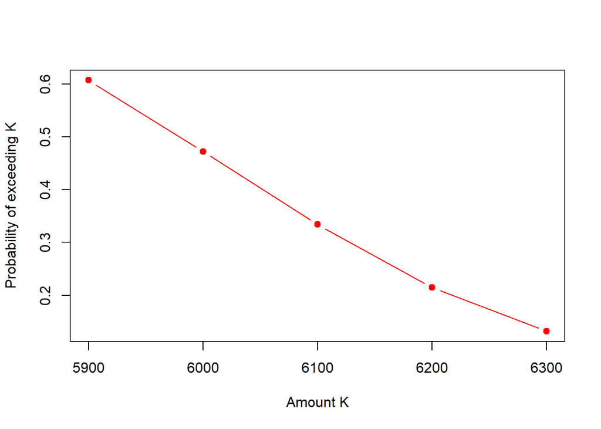

```r
plot(x= K, y=prob, type = "b", pch = 19, col="red", xlab= "Amount K", ylab = "Probability of exceeding K")
```

```r
K <- c()
prob <- c()
for (ks in seq(16400,16800,100)){
    K <- append(K, ks)
    str1 <- insurance_model_probability(K = ks,  t=24, lambda=15, a = 9, beta = 5)
    prob <- append(prob, str1[3])
}
```

```
## [1] "Probability of exceeding the sum K: 16400 in time t: 24 equals: 0.398 for the parameters lambda= 15 ,a= 9 ,beta= 5."
## [1] "Probability of exceeding the sum K: 16500 in time t: 24 equals: 0.353 for the parameters lambda= 15 ,a= 9 ,beta= 5."
## [1] "Probability of exceeding the sum K: 16600 in time t: 24 equals: 0.32 for the parameters lambda= 15 ,a= 9 ,beta= 5."
## [1] "Probability of exceeding the sum K: 16700 in time t: 24 equals: 0.287 for the parameters lambda= 15 ,a= 9 ,beta= 5."
## [1] "Probability of exceeding the sum K: 16800 in time t: 24 equals: 0.247 for the parameters lambda= 15 ,a= 9 ,beta= 5."
```

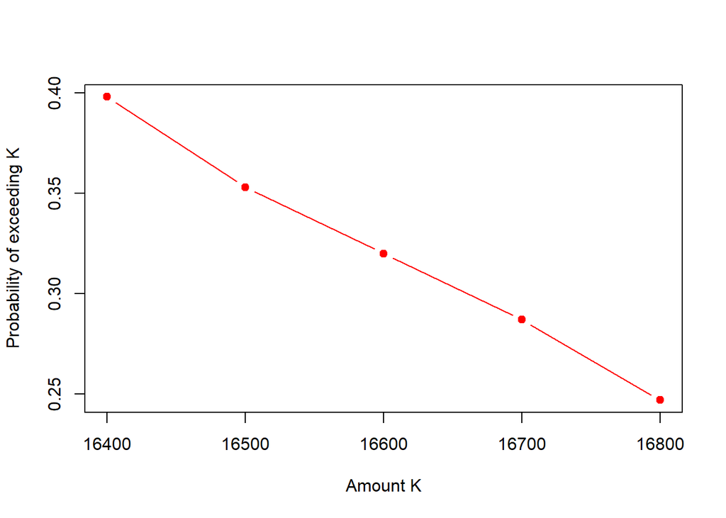

```r
plot(x= K, y=prob, type = "b", pch = 19, col="red", xlab= "Amount K", ylab = "Probability of exceeding K")
```

The conclusions are analogous. Because of the choice of parameters, set 1 has a faster decreasing probability of exceeding a certain amount $K$ in the time interval $[0,t]$, while for set 2 this probability decreases more slowly. Increasing the time interval, therefore, does not “stabilize” our probability of exceeding a certain level of loss. In addition, a seed was set in each simulation to reproduce the results, but the study was previously conducted without this treatment. The results differed in each simulation by sizable amounts, which indicates the high unpredictability of the amount of claims. Obviously, here the parameters were chosen “in the dark,” but it is the appropriate choice of distribution parameters that poses the challenge for correct modeling of the phenomenon.

## 3.7 Summary

In the next project, two generators of numbers from the Gamma distribution were implemented along with a theoretical description. Each of them considered a different case of the parameter $a$, so they were combined into one generator depending on the value of this parameter. Moreover, samples were generated from them and visualized by comparing them to the built-in generators. The results were satisfactory.

In the next part, the previously built generator was transformed from the Poisson distribution in terms of creating a model of the insurance claims process. The sum of loss (insurance claim volume) was considered using a collective risk model using Poisson distributions for frequency modeling and Gamma distributions for claim amount modeling. An example was then considered for different parameter arrangements and for each of them the probability of a loss above a fixed level $K$ was estimated for a certain time interval $[0,t]$. These results were presented in graphical form and subjected to interpretation.

# 4 Implementation of the Monte Carlo method for the Black-Scholes model of option pricing

## 4.1 Introduction

Options are one of the financial instruments that occur on the stock market as well as on the OTC (“over-the-counter market”). There are two types of options, the first is the **call** option, which *gives the option holder the right to purchase a certain asset on a certain date for a certain price*. The second is the **put** option, which in turn *gives the option holder the right to sell a certain asset on a certain date for a certain price*. The price in the contract is known as the strike price / excercise price, and the date contained in the contract is called the expiration date or maturity.

Moreover, we can distinguish between *American* options and *European* options. American options can be exercised at any time up to the expiration date. European options, on the other hand, can only be exercised at the maturity of the contract. Of course, these names do not refer to geographic location.

It is worth noting that an option gives the holder the right to perform a certain action, but this right does not have to be exercised. This is a factor that distinguishes options from forwards and futures, where the holder of such a contract is obliged to buy or sell the corresponding asset. On the other hand, entering into a forward/futures contract does not require a cash contribution, and the purchase of options brings some costs (although here we will assume no-cost options).

In the case of options, it is possible to notice certain relationships to the strike price. When this price rises then mostly the price of call options decreases, and the price of put options increases. In addition, both types of options tend to increase in value when the time to the exercise date increases.

In the options market, we can distinguish four types of participants: call option buyer, call option seller, put option buyer and put option seller. Options are often used in hedging to hedge certain positions taken and investments made.

## 4.2 Profit from options

Let’s denote by $S(t)$ the price of a certain stock at time $t$. Consider a call option that gives the holder the right to buy this stock for a certain price $K$ at a certain future time $T$. Let $t=0$. If at time $T$ the value of the stock price $S(T)$ exceeds the strike price $K$ then the holder will exercise the option earning a profit of $S(T) - K$. On the other hand, if $S(T) \leq K$ then the option will not be exercised and will expire (we are considering a European option, so it can only be exercised at time $T$). In this case, the option holder’s profit at time $T$ is as follows
$$(S(T) - K)^{+} = \max\{0,
S(T)-K\}.$$
This value still needs to be discounted to get the present value of this profit. To do this, we multiply the total by the discount factor $e^{-rT}$, where $r$ is the continuously accruing interest rate. The expected value of the profit is, therefore
$$E[e^{-rT}(S(T) - K)^{+}].$$
For this value to make sense, we need to determine the distribution of the random variable of the stock price $S(T)$.

## 4.3 Black-Scholes model

Instead of specifying the distribution at a specific time, we will introduce a model to represent the dynamics of the stock price. A model that describes the evolution of this price through stochastic differential equations (“stochastic differential equations”). “stochastic differential equations (SDE)”) is the Black-Scholes model, which describes equation
$$\frac{dS(T)}{S(t)}
= rdt + \sigma dW(t),$$
where $W$ is the standard Brownian motion. This equation can be interpreted as modeling the percentage change in $dS/S$ of the stock price through increments of Brownian motion. The parameter $dSigma$ denotes the volatility of the stock price, and the factor at $dt$ is the average rate of return. If we consider the average rate of return as equal to the interest rate $r$ then we will be directly determining the risk-neutral dynamics of the stock price.

The solution to this stochastic differential equation, or the equation describing the Black-Scholes model, is as follows
$$S(T) = S(0)\cdot exp([r-\frac{1}{2}\sigma^2]T +
\sigma \sqrt{T}Z).$$
Thus, the logarithm of the stock price has a normal distribution, and the stock price itself has a log-normal distribution. The expected value $E[e^{-rT}(S(T)-K)^{+}]$ is an integral due to the density of the log-normal distribution of $S(T)$. This integral can be estimated by the distribution of the normal distribution $\Phi$ as $BS(S(0),\sigma, T, r, K)$, where
$$BS(S, \sigma, T, r, K) = S\Phi(\frac{\log{(S/K)}
+ (r+\frac{1}{2}\sigma^2)T}{\sigma\sqrt{T}}) -
e^{-rT}K\Phi(\frac{\log{(S/K)} +
(r-\frac{1}{2}\sigma^2)T}{\sigma\sqrt{T}}).$$
The above formula is the Black-Scholes formula for call options.

## 4.4 The current expected value of the European option profit.

From the SSD equation, we can see that in order to draw a sample of stock prices $S(T)$ a mechanism is required to draw samples from a standard normal distribution. We implemented such a mechanism in a previous project and I will use it for this issue. Specifically, we are talking about the Box-Muller algorithm, only this time we will use the built-in generator of numbers from a uniform distribution for readability.

```r
normal_box <- function(N){
  X <- c()

  while(length(X) < N){

    U <- runif(2)
    U1 <- U[1]
    U2 <- U[2]
    R <- -2*log(U1)
    V <- 2*pi*U2

    Z1 <- sqrt(R)*cos(V)
    Z2 <- sqrt(R)*sin(V)


    X <- append(X,c(Z1,Z2))
    }

  return(X)
}
```

So we assume that we are generating a vector $Z = (Z_1, Z_2, ...)$ of independent random variables with a normal standard distribution. Having the ability to generate $Z_i$, we can estimate $E[e^{-rT}(S(T)-K)^{+}]$ with the following algorithm:

```r
expected_value <- function(N, s, r, K, sigma, Ti){
  # N - number of iterations
  # s - initial value of shares
  # r - interest rate
  # sigma - share price volatility
  # Ti - time of option exercise

  C <- rep(0, N)
  S <- rep(0, N)

  Z <- normal_box(N)
  for (i in 1:N){
    S[i] <- s*exp((r-1/2*sigma^2)*Ti + sigma*sqrt(Ti)*Z[i])
    C[i] <- exp(-r*Ti)*max(0, S[i] - K)
  }

  return(C)
}
```

```r
confidence_interval <- function(alpha, C){
  # alpha - confidence parameter, alpha = 0.01, 0.05, 0.1
  # C_avg - expected value of profit
  # C - vector of random variables of profit
  C_avg <- mean(C)

  if (alpha == 0.01){
    z_alpha <- 2.58
  } else if (alpha == 0.05){
    z_alpha <- 1.96
  } else if (alpha == 0.1){
    z_alpha <- 1.64
  } else{
    z_alpha <- "Not implemented!"
  }

  s_c <- sqrt((sum(C-C_avg)^2)/(length(C)-1))

  interval <- z_alpha*s_c/sqrt(length(C))
  return(interval)
}
```

Now we will create a function that returns both the expected value and the confidence interval.

```r
combine <- function(N, s, r, K, sigma, Ti, alpha){
  C <- expected_value(N, s, r, K, sigma, Ti)
  inter <- confidence_interval(alpha, C)

  return(c(mean(C), inter))
}
```

Such a function will return a vector composed of the expected value of the option’s profit and a confidence interval.

## 4.5 Tesla stock prices and the BS model

Let’s consider a one-year history (from Feb 24, 2022 to Feb 24, 2023) of data for Tesla’s stock prices in dollars. Let’s load this data, which we download from the page [finance.yahoo.com/quote/TSLA](https://finance.yahoo.com/quote/TSLA/history?p=TSLA).

```r
data <- read.csv("TSLA.csv")
head(data)
```

```
##         Date     Open     High      Low    Close Adj.Close   Volume
## 1 2022-02-25 269.7433 273.1667 260.8000 269.9567  269.9567 76067700
## 2 2022-02-28 271.6700 292.2867 271.5700 290.1433  290.1433 99006900
## 3 2022-03-01 289.8933 296.6267 284.5933 288.1233  288.1233 74766900
## 4 2022-03-02 290.7100 295.4933 281.4233 293.2967  293.2967 74643300
## 5 2022-03-03 292.9233 295.4800 277.5333 279.7633  279.7633 61623600
## 6 2022-03-04 283.0333 285.2167 275.0533 279.4300  279.4300 66999600
```

We have exactly 254 rows, or 254 days on which the stock market was open. We need to sort our data, discard gaps and calculate percentage gains, i.e. subtract the previous day’s closing price from the closing price on a given day and divide by it.

```r
data <- data[order(data$Date),]
data <- na.omit(data)
data["close_day_before"] <- c(NA, head(data$Close, -1))
data["returns"] = ((data$Close - data$close_day_before)/data$close_day_before)
head(data)
```

```
##         Date     Open     High      Low    Close Adj.Close   Volume
## 1 2022-02-25 269.7433 273.1667 260.8000 269.9567  269.9567 76067700
## 2 2022-02-28 271.6700 292.2867 271.5700 290.1433  290.1433 99006900
## 3 2022-03-01 289.8933 296.6267 284.5933 288.1233  288.1233 74766900
## 4 2022-03-02 290.7100 295.4933 281.4233 293.2967  293.2967 74643300
## 5 2022-03-03 292.9233 295.4800 277.5333 279.7633  279.7633 61623600
## 6 2022-03-04 283.0333 285.2167 275.0533 279.4300  279.4300 66999600
##   close_day_before      returns
## 1               NA           NA
## 2         269.9567  0.074777468
## 3         290.1433 -0.006962142
## 4         288.1233  0.017955294
## 5         293.2967 -0.046142104
## 6         279.7633 -0.001191518
```

We will treat our volatility as the annual standard deviation from returns.

```r
sigma <- sqrt(254)*sd(data$returns, na.rm=TRUE)
sigma
```

```
## [1] 0.678202
```

We will also load option data for April 21, 2023 from the page [finance.yahoo.com/quote/TSLA/options](https://finance.yahoo.com/quote/TSLA/options?date=1682035200&p=TSLA) so we are 39 days away from the execution date therefore $T=39/254$.

```r
library(rvest)
theurl <- 'https://finance.yahoo.com/quote/TSLA/options?date=1682035200&p=TSLA'
file<-read_html(theurl)
tables<-html_nodes(file, "table")
r <- as.data.frame(html_table(tables[1], fill = TRUE))
r$Strike <- gsub(",","",r$Strike)
r$Strike <- as.numeric(r$Strike)
head(r)
```

```
##         Contract.Name        Last.Trade.Date Strike Last.Price    Bid    Ask
## 1 TSLA230421C00005000  2023-01-30 9:40AM EST      5     169.38 191.40 192.40
## 2 TSLA230421C00020000  2023-02-23 3:08PM EST     20     181.60 176.85 177.20
## 3 TSLA230421C00025000  2023-02-23 3:08PM EST     25     176.65 171.90 172.25
## 4 TSLA230421C00030000 2023-01-24 10:12AM EST     30     112.75 167.80 168.20
## 5 TSLA230421C00035000  2023-01-26 1:03PM EST     35     123.64 161.95 162.35
## 6 TSLA230421C00040000 2023-02-16 12:09PM EST     40     176.25 157.00 157.40
##   Change X..Change Volume Open.Interest Implied.Volatility
## 1      0         -     14            14            325.00%
## 2      0         -      5             9            242.58%
## 3      0         -      5             7            226.56%
## 4      0         -      1             0            270.90%
## 5      0         -      -             5            197.46%
## 6      0         -      1             7            186.72%
```

We can see that we have 151 different strike prices, but we will make estimates for the first 50. For each of the strike prices $K$, we will take the current (as of 24/02/2023) stock price $S_0$ as the starting price $S_0$ i.e. $S_0 = 196.88.$ As the interest rate, we will take *The 10 Year Treasury Rate* as the risk-free rate when pricing the market or a single security. This is the rate achieved when investing in US Treasury bonds. As of today (24.02.2023) we will assume $r=0.0394$. The Bid and Ask prices appear on the stock market, the former denoting the price at which we can sell the option and the latter at which we can buy it. Let’s compare, then, our estimated prices to those actually proposed.

```r
n <- 50
estimates <- rep(0,n)
conf_intervals <- rep(0,n)

for (i in 1:n){
  res <- combine(N=1000, s=196.88, r=0.0395, K=r$Strike[i], sigma=sigma, Ti=39/254, alpha =0.05)

  estimates[i] <- res[1]
  conf_intervals[i] <- res[2]
}

errors <- cbind(r[1:50,], estimates, conf_intervals)
errors['estimate_error'] <- ((errors$Ask - errors$estimates)/errors$estimates)*100
summary(errors$estimate_error)
```

```
##    Min. 1st Qu.  Median    Mean 3rd Qu.    Max.
## -4.4471 -0.2829  1.1211  1.2244  2.2290  7.6078
```

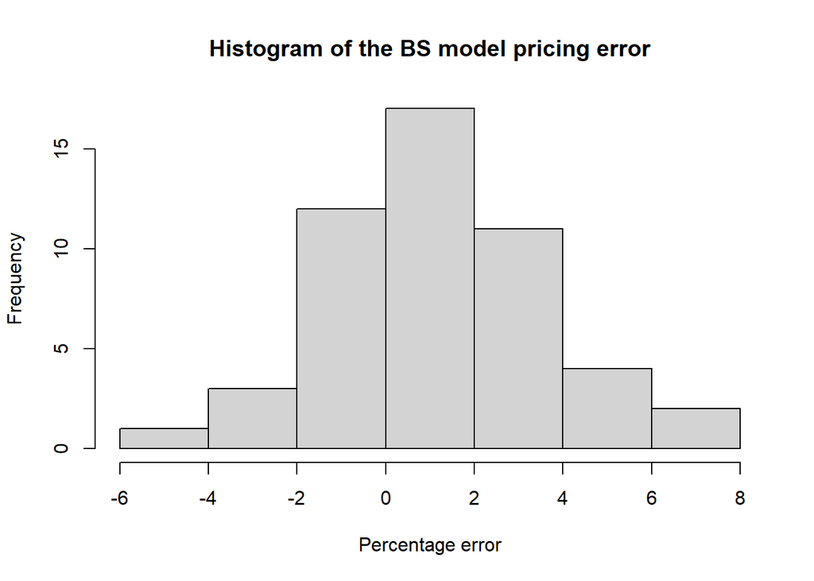

```r
hist(errors$estimate_error, main="Histogram of the BS model pricing error", xlab="Percentage error")
```

```r
n <- 50
ints <- rep(0,n)

for (alpha in c(0.01,0.05,0.1)){
  for (i in 1:n){
    ints[i] <- combine(N=1000, s=196.88, r=0.0394, K=r$Strike[i], sigma=sigma, Ti=39/254,
              alpha =alpha)[2]
  }
  print(paste("The maximum value of the confidence interval for alpha = ", alpha, " equals: ", max(ints)))
  print(paste("The minimum value of the confidence interval for alpha = ", alpha, " equals: ", min(ints)))
  print(paste("The average value of the confidence interval for alpha = ", alpha, " equals: ", mean(ints)))

}
```

```
## [1] "The maximum value of the confidence interval for alpha =  0.01  equals:  3.5031645136501e-14"
## [1] "The minimum value of the confidence interval for alpha =  0.01  equals:  5.50235263924099e-17"
## [1] "The average value of the confidence interval for alpha =  0.01  equals:  9.46088268672694e-15"
## [1] "The maximum value of the confidence interval for alpha =  0.05  equals:  2.61951795931204e-14"
## [1] "The minimum value of the confidence interval for alpha =  0.05  equals:  3.13506138747452e-17"
## [1] "The average value of the confidence interval for alpha =  0.05  equals:  7.3835224097029e-15"
## [1] "The maximum value of the confidence interval for alpha =  0.1  equals:  2.19184155779171e-14"
## [1] "The minimum value of the confidence interval for alpha =  0.1  equals:  3.78908779937396e-17"
## [1] "The average value of the confidence interval for alpha =  0.1  equals:  5.44722176720923e-15"
```

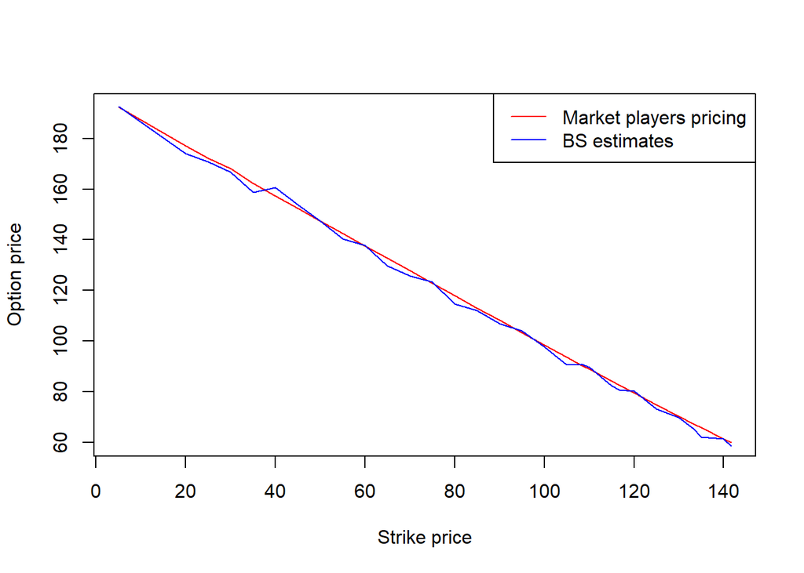

```r
plotting <- errors[1:30,]
plot(plotting$Strike, plotting$Ask, type = "l", col = "red", xlab="Strike price", ylab="Option price")
lines(plotting$Strike, plotting$estimates, type = "l", col ="blue")
legend(x = "topright", legend = c("Market players pricing", "BS estimates"), col=c("red","blue"),
       lty=1:1)
```

We can see that, indeed, the BS model estimates are close to the valuations by stock market players. We can also see the relationship mentioned at the beginning of the paper, i.e. as the strike price increases, the option price decreases. This is, of course, influenced by the decreasing possible profit from this contract.

Now let’s check the situation in which we would adapt the volatility used by the stock players. To the previous code I add the column transformation to numeric and divide by the percentage. Recall that our chosen initial value was $= $67.82%.

```r
n <- 50
estimates2 <- rep(0,n)
conf_intervals2 <- rep(0,n)

r['sigma2'] <- gsub("%","",r$Implied.Volatility)
r$sigma2 <- as.numeric(r$sigma2)/100

for (i in 1:n){
  res2 <- combine(N=1000, s=196.88, r=0.0394, K=r$Strike[i], sigma=r$sigma2[i], Ti=39/254, alpha =0.05)

  estimates2[i] <- res2[1]
  conf_intervals2[i] <- res2[2]
}

errors2 <- cbind(r[1:100,], estimates2, conf_intervals2)
errors2['estimate_error'] <- ((errors2$Ask - errors2$estimates)/errors2$estimates)*100
summary(errors2$estimate_error)
```

```
##    Min. 1st Qu.  Median    Mean 3rd Qu.    Max.
##  -98.00  -96.48  -50.96  -48.16   -1.07   14.05
```

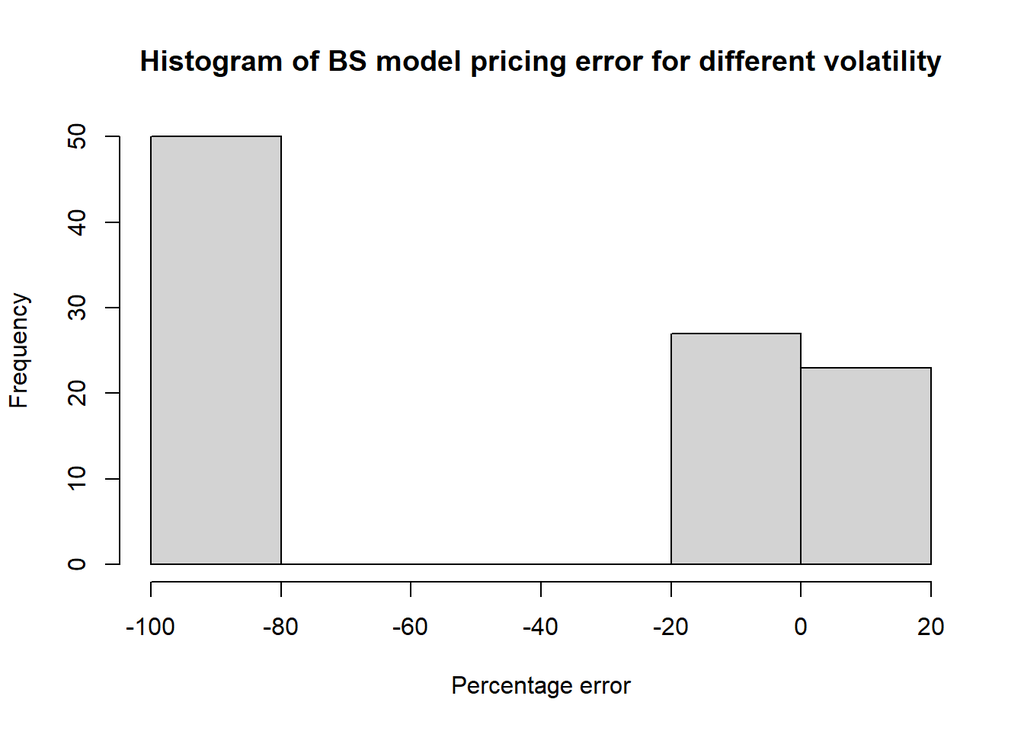

```r
hist(errors2$estimate_error ,main="Histogram of BS model pricing error for different volatility", xlab="Percentage error")
```

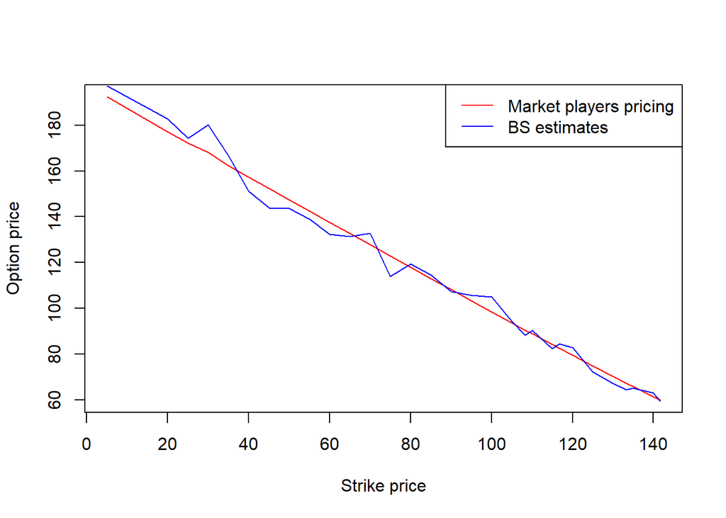

```r
plotting2 <- errors2[1:30,]
plot(plotting2$Strike, plotting2$Ask, type = "l", col = "red", xlab="Strike price", ylab="Option price")
lines(plotting2$Strike, plotting2$estimates, type = "l", col ="blue")
legend(x = "topright", legend = c("Market players pricing", "BS estimates"), col=c("red","blue"),
       lty=1:1)
```

Indeed, stronger biases are evident. This volatility gives us a sense of the extent to which future players will price options if they are rational. Therefore, these stronger deviations are present. The applied volatility from the set is much higher than the one we chose, which affects the stronger variance.

Let’s now take the median strike price $K=340$ and analyze some properties of the BS model at this value. First, let’s check the course of changes in the average valuation with increasing time series $T$.

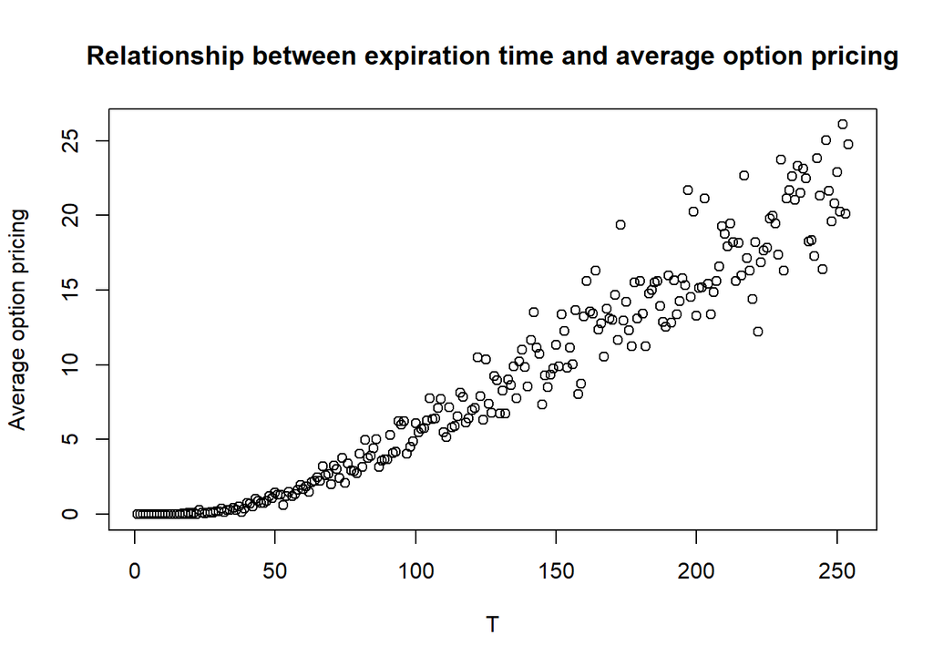

```r
E <- rep(0, 254)
Tn <- seq(1,254)
for (i in 1:254){
  E[i] <- combine(N=1000, s=196.88, r=0.0394, K=340, sigma=sigma, Ti=i/254,
              alpha =alpha)[1]

}
plot(Tn, E, main="Relationship between expiration time and average option pricing", xlab="T", ylab="Average option pricing")
```

```r
print(paste("Average standard deviation from valuation: ", sd(E)))
```

```
## [1] "Average standard deviation from valuation:  7.26366452307534"
```

## 4.6 Summary

Options are one of the financial instruments that give the holder the right to buy or sell options. They are a great way to reduce risk when buying assets. Using the Black-Scholes model, which is a mathematical model of the market that describes the price dynamics of financial instruments over time, we are able, given the right information, to model in some way the value of an option for a given (for example) stock by determining the expected profit from the purchase of that option.

In discussing and creating the model, we assumed no costs arising from the purchase or sale of the contract. To test the model empirically, we took Tesla, Inc. stock from the past year and option prices with an exercise date within the next month and a half. Based on this data, we created a model and checked its average error. We also briefly analyzed the confidence intervals of the results obtained, as well as the effect of the time of option exercise and the volatility parameter. The initial results were relatively satisfactory. The influence of the time of option expiration was also evident.

The Black-Scholes model is often used for valuation because of its simplicity. However, it has certain assumptions like no arbitrage, no risk of borrowing and placing cash at the same interest rate, no transaction costs or no dividend payments, which are not very realistic. This makes it able to perform not very well in its classic form in the market reality.

# Bibliography

1.

Glasserman P (2004) Monte Carlo methods in financial engineering, Springer.

2.

Z. Amin JB K. Antonio (2020) Loss Data Analytics. An open text authored by the Actuarial Community (acessed 31-January-2022 from https://openacttexts.github.io/Loss-Data-Analytics/).

3.

Torino B (2020) Systematically Pricing Financial Options With Black Scholes (accessed 31-January-2022 from https://towardsdatascience.com/systematically-pricing-financial-options-with-black-scholes-4998c591ccbd).